# FPP - Ch. 5 Exercises

##### Time Series Regression Models

##### Dan Hong | dnaeye@gmail.com

The following are my answers to the exercises in the excellent book [Forecasting: Principles & Practice](https://otexts.org/fpp2/) by Rob J Hyndman and George Athanasopoulos.

#### 1. Create a regression model and forecasts for electricity demand in Victoria, Australia.

**1a.** Plot the data and find the regression model for Demand with temperature as an explanatory variable. Why is there a positive relationship?

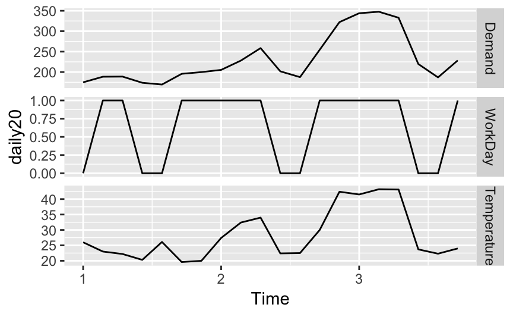

```r
library(fpp2)
daily20 <- head(elecdaily,20)
autoplot(daily20, facets=TRUE)
```

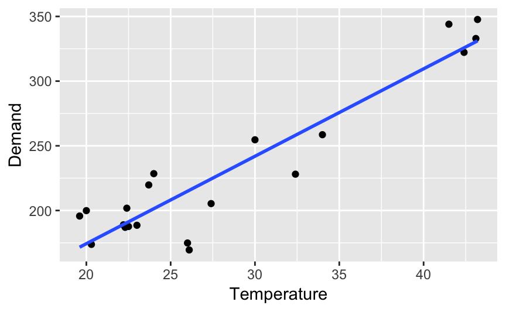

```r
daily20 %>%
  as.data.frame() %>%
  ggplot(aes(x=Temperature, y=Demand)) +
  geom_point() +
  geom_smooth(method="lm", se=FALSE)
```

```r
fit <- tslm(Demand ~ Temperature, data=daily20)
```

When the temperature goes up, electricity demand goes up as well because of air conditioning needs. **1b.** Produce a residual plot. Is the model adequate? Are there any outliers or influential observations?

```
    Breusch-Godfrey test for serial correlation of
    order up to 5

data:  Residuals from Linear regression model
LM test = 3.8079, df = 5, p-value = 0.5774
```

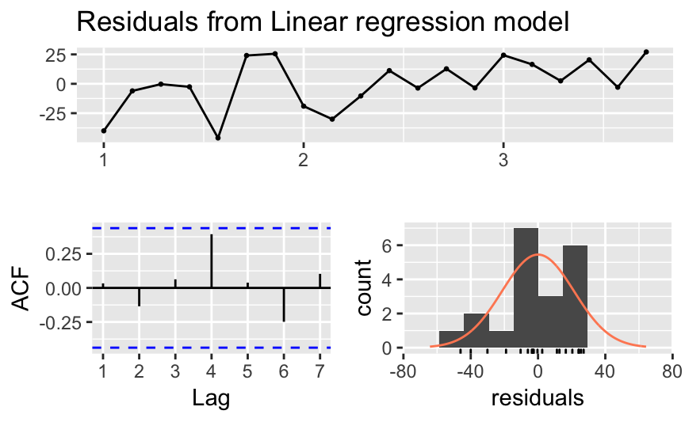

```r
checkresiduals(fit)
```

Based on the high p-value from the Breusch-Godfrey test and the absence of lags with significant ACF, the model is adequate. The residuals plot indicates there were significant outliers where the actual demand was much lower than the expected demand.

**1c.** Use the model to forecast the electricity demand that you would expect for the next day if the maximum temperature was15 degrees and compare it with the forecast if the with maximum temperature was 35 degrees. Do you believe these forecasts?

```r
test <- data.frame(Temperature = c(15, 35))
fc <- forecast(fit, test)
```

The point forecasts at both 15 degrees and 35 degrees, which were 141 and 276 degrees, respectively, were good predictions, based on the line chart from Exer. 1a.

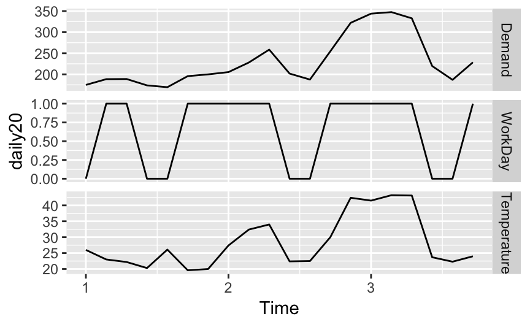

```r
autoplot(daily20, facets=TRUE)
```

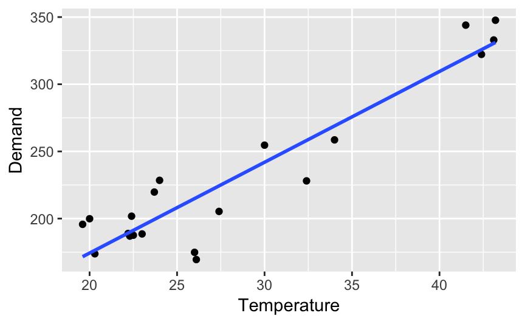

```r
daily20 %>%
  as.data.frame() %>%
  ggplot(aes(x=Temperature, y=Demand)) +
  geom_point() +
  geom_smooth(method="lm", se=FALSE)
```

```
    Breusch-Godfrey test for serial correlation of
    order up to 5

data:  Residuals from Linear regression model
LM test = 3.8079, df = 5, p-value = 0.5774
```

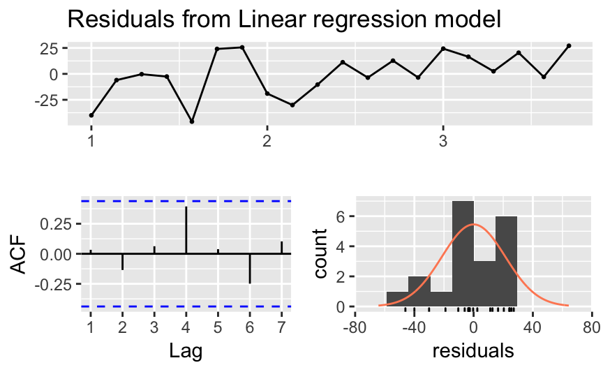

```r
fit <- tslm(Demand ~ Temperature, data=daily20)
checkresiduals(fit)
```

```r
forecast(fit, newdata=data.frame(Temperature=c(15,35)))
```

```
         Point Forecast    Lo 80    Hi 80     Lo 95
3.857143       140.5701 108.6810 172.4591  90.21166
4.000000       275.7146 245.2278 306.2014 227.57056
            Hi 95
3.857143 190.9285
4.000000 323.8586
```

**1e.** Plot Demand vs Temperature for all of the available data in elecdaily. What does this say about your model?

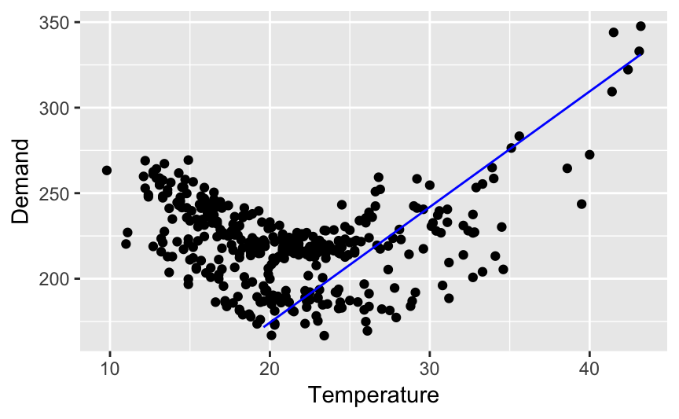

```r
elecdaily %>%
  as.data.frame() %>%
  ggplot(aes(Temperature, Demand)) +
  geom_point() +
  geom_line(data=fortify(fit), aes(x=Temperature, y=.fitted), color="blue")
```

Whne plotting my original model, which was based on just the first 20 days of 2014, it’s obvious that it did not adequately explain patterns for the rest of the year. It failed to explain any temperature lower than 20 degrees, for which the data shows an upward trend in demand as temperatures decreased. A possible explanation for this could be that during colder weather, people tended to stay indoors and use electric heaters.

#### 2. Data set mens400 contains the winning times (in seconds) for the men’s 400 meters final in each Olympic Games from 1896 to 2016.

**2a.** Plot the winning time against the year. Describe the main features of the plot.

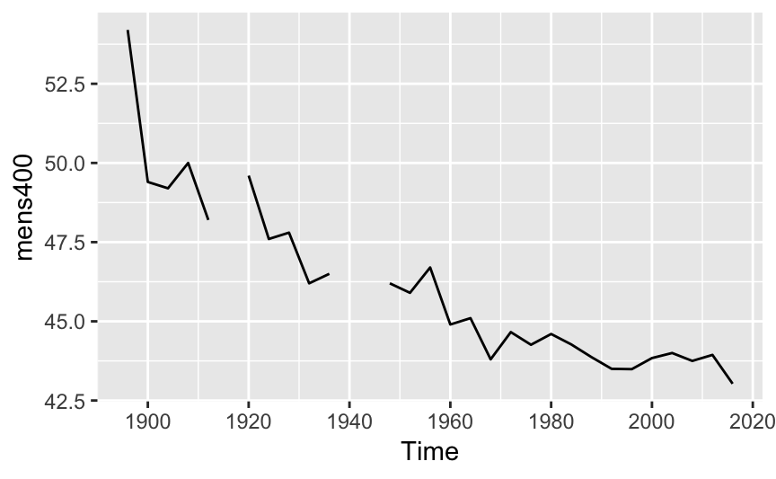

```r
autoplot(mens400)
```

There is a general negative trend with a few gaps of data between 1910 and 1920 and again from 1935 to 1948 (all years approximate).

**2b.** Fit a regression line to the data. Obviously the winning times have been decreasing, but at what average rate per year?

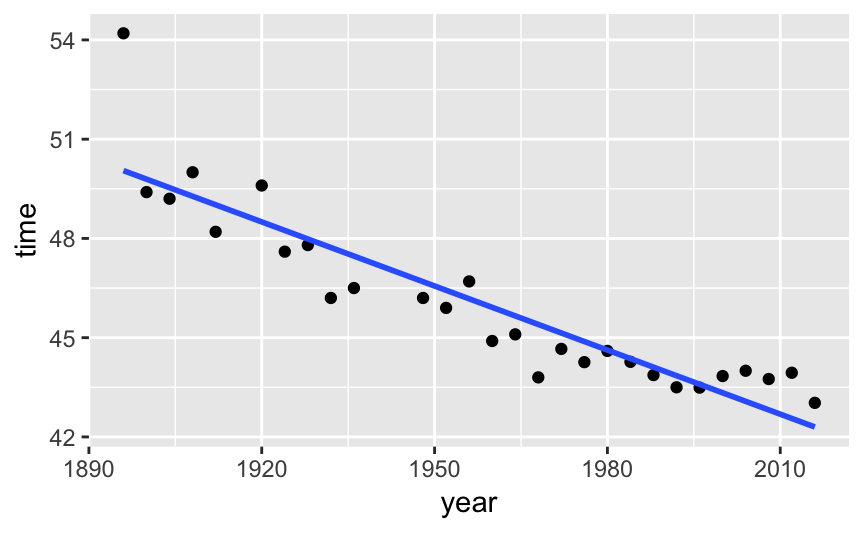

```r
mens400 %>%
  as.data.frame() %>%
  ggplot(aes(x=as.numeric(time(mens400)), y=as.numeric(mens400))) +
  xlab("year") + ylab("time") +
  geom_point() +
  geom_smooth(method="lm", se=FALSE)
```

```r
m400.fit <- tslm(mens400 ~ trend)
```

**2c.** Plot the residuals against the year. What does this indicate about the suitability of the fitted line?

```
    Breusch-Godfrey test for serial correlation of
    order up to 6

data:  Residuals from Linear regression model
LM test = 3.6082, df = 6, p-value = 0.7295
```

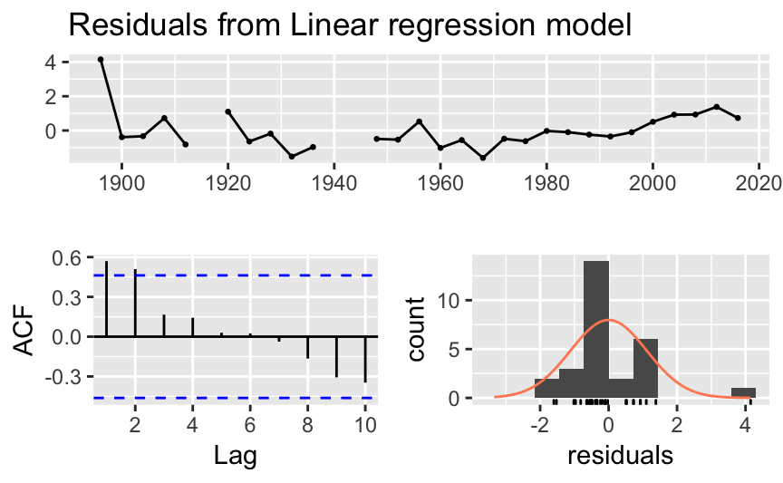

```r
checkresiduals(m400.fit)
```

**2d.** Predict the winning time for the men’s 400 meters final in the 2020 Olympics. Give a prediction interval for your forecasts. What assumptions have you made in these calculations?

```r
forecast(m400.fit, h=1)
```

```
  Point Forecast Lo 80 Hi 80 Lo 95 Hi 95
1       42.04231    NA    NA    NA    NA
```

The forecast using time-series linear regression for the winning time in 2020 is `42.04`.

Because the trend resembles a random walk, the `rwf` model would be appropriate to make a forecast with a prediction interval.

```r
rwf(mens400, drift=T, h=1)
```

```
     Point Forecast    Lo 80    Hi 80    Lo 95    Hi 95
2020       42.65767 41.15096 44.16438 40.35335 44.96198
```

#### 3. Type easter(ausbeer) and interpret what you see.

```r
easter(ausbeer)
```

```
     Qtr1 Qtr2 Qtr3 Qtr4
1956 0.67 0.33 0.00 0.00
1957 0.00 1.00 0.00 0.00
1958 0.00 1.00 0.00 0.00
1959 1.00 0.00 0.00 0.00
1960 0.00 1.00 0.00 0.00
1961 0.33 0.67 0.00 0.00
1962 0.00 1.00 0.00 0.00
1963 0.00 1.00 0.00 0.00
1964 1.00 0.00 0.00 0.00
1965 0.00 1.00 0.00 0.00
1966 0.00 1.00 0.00 0.00
1967 1.00 0.00 0.00 0.00
1968 0.00 1.00 0.00 0.00
1969 0.00 1.00 0.00 0.00
```

[output cut: 41 more lines]

The `easter` function indicates with a `1` for the quarter in which the Easter holiday occurs for each year.

#### 4. An elasticity coefficient is the ratio of the percentage change in the forecast variable $y$ to the percentage change in the predictor variable $x$.

Mathematically, the elasticity is defined as $(dy/dx) \times (x/y)$. Consider the log-log model,
$$log~y = \beta_0 + \beta_1log~x + E$$
Express $y$ as a function of $x$ and show that the coefficient $\beta_1$ is the elasticity coefficient.

If you take the exponentials of both sides,

$$y = \epsilon^{\beta_0} + x^{\beta_1} + \epsilon^E$$
I do not know how to show that the coefficient $\beta_1$ is the elasticity coefficient.

#### 5. The data set fancy concerns the monthly sales figures of a shop which opened in January 1987 and sells gifts, souvenirs, and novelties.

The shop is situated on the wharf at a beach resort town in Queensland, Australia. The sales volume varies with the seasonal population of tourists. There is a large influx of visitors to the town at Christmas and for the local surfing festival, held every March since 1988. Over time, the shop has expanded its premises, range of products, and staff.

**5a.** Produce a time plot of the data and describe the patterns in the graph. Identify any unusual or unexpected fluctuations in the time series.

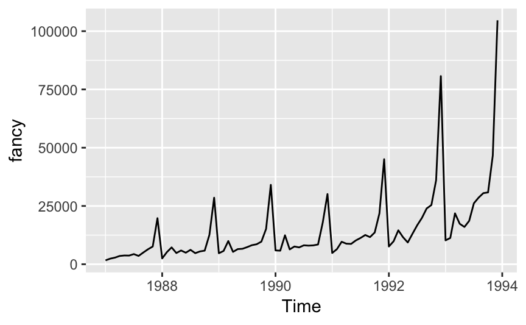

```r
autoplot(fancy)
```

As noted in the description of the dataset, there were seasonal spikes in December and a smaller one every March since 1988. There has also been an upward trend since 1991.

**5b.** Explain why it is necessary to take logarithms of these data before fitting a model.

The data should be log transformed because the seasonal variances are increasing.

**5c.** Use R to fit a regression model to the logarithms of these sales data with a linear trend, seasonal dummies and a “surfing festival” dummy variable.

```r
dummy_fest = rep(0, length(fancy))
dummy_fest[seq_along(dummy_fest)%%12 == 3] <- 1
dummy_fest[3] <- 0 #festival started one year later
dummy_fest = ts(dummy_fest, freq = 12, start=c(1987,1))
fancy.fit <- tslm(fancy ~ trend + season + dummy_fest, lambda=0)
summary(fancy.fit)
```

```
Call:
tslm(formula = fancy ~ trend + season + dummy_fest, lambda = 0)

Residuals:
     Min       1Q   Median       3Q      Max
-0.33673 -0.12757  0.00257  0.10911  0.37671

Coefficients:
             Estimate Std. Error t value Pr(>|t|)
(Intercept) 7.6196670  0.0742471 102.626  < 2e-16 ***
trend       0.0220198  0.0008268  26.634  < 2e-16 ***
season2     0.2514168  0.0956790   2.628 0.010555 *
season3     0.2660828  0.1934044   1.376 0.173275
season4     0.3840535  0.0957075   4.013 0.000148 ***
season5     0.4094870  0.0957325   4.277 5.88e-05 ***
season6     0.4488283  0.0957647   4.687 1.33e-05 ***
season7     0.6104545  0.0958039   6.372 1.71e-08 ***
season8     0.5879644  0.0958503   6.134 4.53e-08 ***
season9     0.6693299  0.0959037   6.979 1.36e-09 ***
season10    0.7473919  0.0959643   7.788 4.48e-11 ***
season11    1.2067479  0.0960319  12.566  < 2e-16 ***
season12    1.9622412  0.0961066  20.417  < 2e-16 ***
dummy_fest  0.5015151  0.1964273   2.553 0.012856 *
---
Signif. codes:
0 ‘***’ 0.001 ‘**’ 0.01 ‘*’ 0.05 ‘.’ 0.1 ‘ ’ 1

Residual standard error: 0.179 on 70 degrees of freedom
Multiple R-squared:      1, Adjusted R-squared:      1
F-statistic: 4.105e+10 on 13 and 70 DF,  p-value: < 2.2e-16
```

**5d.** Plot the residuals against time and against the fitted values. Do these plots reveal any problems with the model?

```
    Breusch-Godfrey test for serial correlation of
    order up to 17

data:  Residuals from Linear regression model
LM test = 37.954, df = 17, p-value = 0.002494
```

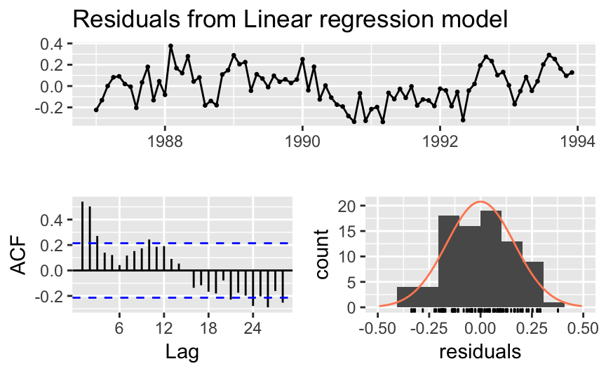

```r
checkresiduals(fancy.fit)
```

```
not plotting observations with leverage one:
  3
```

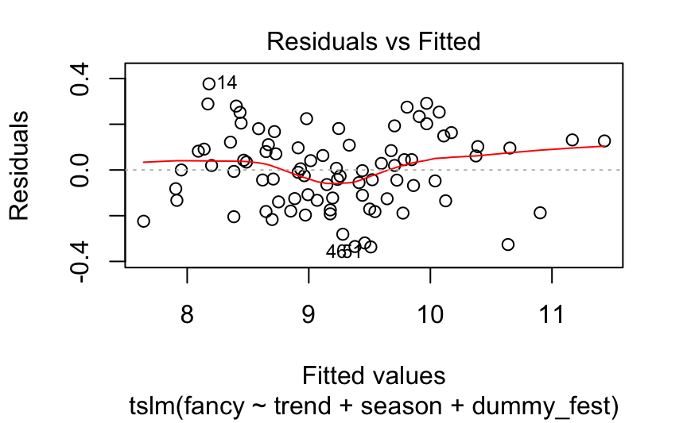

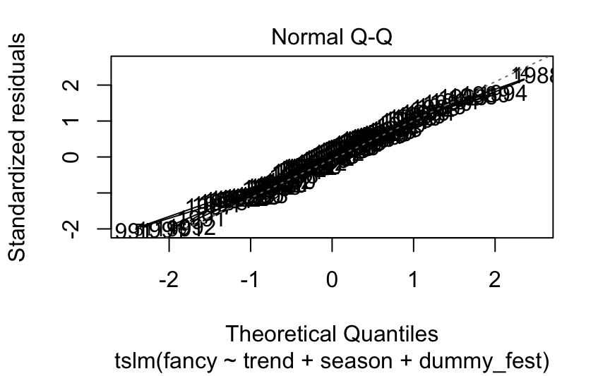

```
not plotting observations with leverage one:
  3
```

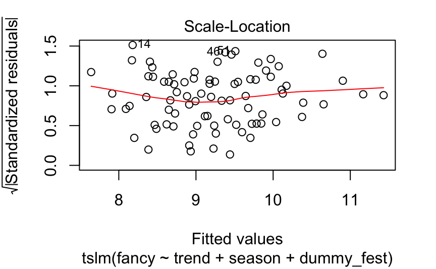

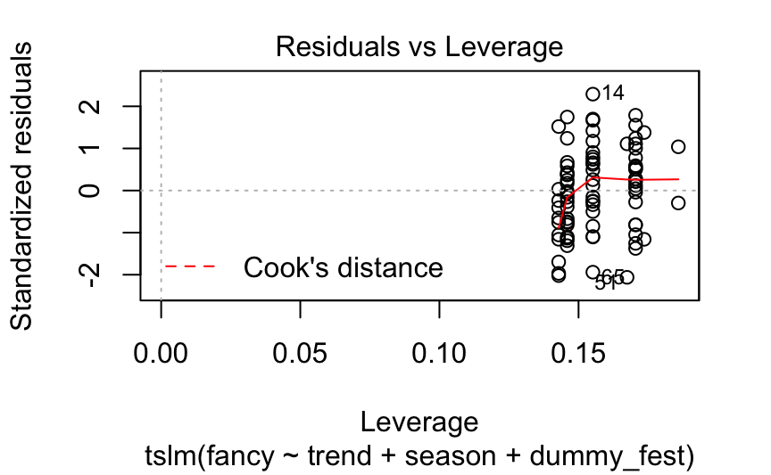

```r
plot(fancy.fit)
```

The residuals vs. fitted plot shows a slight parabola in the middle range of fitted values, indicating that for this range of values, the model is predicting significantly higher than the actual observed values.

**5e.** Do boxplots of the residuals for each month. Does this reveal any problems with the model?

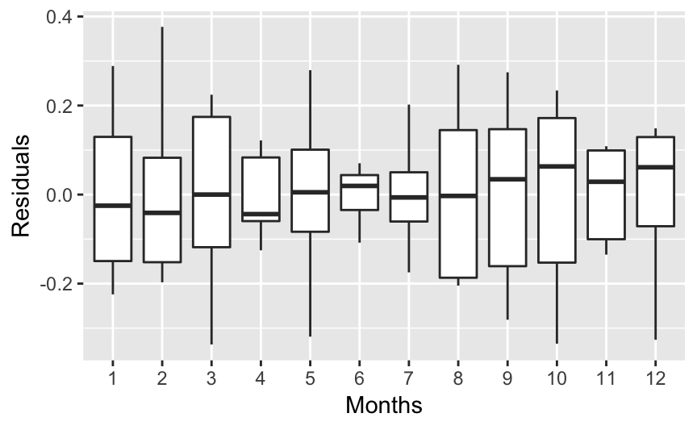

```r
ggplot() + geom_boxplot(mapping=aes(x=month.factor, y=as.numeric(residuals(fancy.fit)))) + labs(x = "Months", y = "Residuals")
```

The boxplot of residuals reveals that the model produces a lot of variance in March and in the fall months, from August to October.

**5f.** What do the values of the coefficients tell you about each variable?

The log-transformed coefficients for each month tell us how large the sales are in relation to January’s sales. For example, the coefficient for December (i.e., season12) is about 1.96, but because the model has a lambda of 0, all fitted values have been log transformed. To get the true multiplier for December, you need to raise natural log to a power of 1.96: $\epsilon^{1.96}$ = 7.0993271

**5g.** What does the Breusch-Godfrey test tell you about your model?

**5h.** Regardless of your answers to the above questions, use your regression model to predict the monthly sales for 1994, 1995, and 1996. Produce prediction intervals for each of your forecasts.

```r
future_data = rep(0, length(fancy))
future_data[seq_along(future_data)%%12 == 3] <- 1
forecast(fancy.fit, newdata=future_data)
```

```
newdata column names not specified, defaulting to first variable required.
```

```
         Point Forecast     Lo 80     Hi 80      Lo 95
Jan 1994       13244.70  10285.82  17054.73   8969.583
Feb 1994       17409.81  13520.45  22418.00  11790.284
Mar 1994       29821.65  23129.40  38450.24  20155.412
Apr 1994       20774.16  16133.21  26750.16  14068.696
May 1994       21783.73  16917.24  28050.15  14752.395
Jun 1994       23162.27  17987.81  29825.24  15685.969
Jul 1994       27831.56  21613.98  35837.72  18848.111
Aug 1994       27818.48  21603.82  35820.87  18839.249
Sep 1994       30848.42  23956.87  39722.43  20891.193
Oct 1994       34095.57  26478.61  43903.67  23090.230
Nov 1994       55176.84  42850.31  71049.28  37366.903
Dec 1994      120067.79  93244.59 154607.08  81312.400
Jan 1995       17250.40  13357.65  22277.59  11629.938
Feb 1995       22675.20  17558.28  29283.31  15287.252
Mar 1995       38840.85  30046.98  50208.44  26146.972
Apr 1995       27057.06  20951.33  34942.16  18241.435
May 1995       28371.96  21969.51  36640.25  19127.918
Jun 1995       30167.42  23359.80  38958.95  20338.387
Jul 1995       36248.88  28068.91  46812.70  24438.412
Aug 1995       36231.84  28055.72  46790.69  24426.922
Sep 1995       40178.16  31111.50  51887.06  27087.467
Oct 1995       44407.37  34386.35  57348.77  29938.733
Nov 1995       71864.42  55647.40  92807.48  48449.831
Dec 1995      156380.86 121091.75 201954.08 105429.448
Jan 1996       22467.57  17336.40  29117.46  15065.329
Feb 1996       29533.04  22788.25  38274.14  19802.984
Mar 1996       50587.81  39009.73  65602.25  33887.802
Apr 1996       35240.15  27191.96  45670.42  23629.808
May 1996       36952.72  28513.41  47889.88  24778.151
Jun 1996       39291.20  30317.82  50920.48  26346.183
Jul 1996       47211.93  36429.60  61185.57  31657.322
Aug 1996       47189.73  36412.48  61156.80  31642.439
Sep 1996       52329.57  40378.47  67817.91  35088.887
Oct 1996       57837.85  44628.77  74956.52  38782.394
Nov 1996       93598.96  72222.70 121302.09  62761.521
Dec 1996      203676.38 157160.50 263959.89 136572.460
Jan 1997       29262.62  22487.24  38079.41  19498.089
Feb 1997       38464.96  29558.90  50054.40  25629.732
Mar 1997       65887.49  50616.27  85766.11  43880.591
```

[output cut: 115 more lines]

```
Oct 1999 194707.60
Nov 1999 315095.17
Dec 1999 685664.12
Jan 2000  99375.70
Feb 2000 130626.79
Mar 2000 223549.64
Apr 2000 155869.74
May 2000 163444.58
Jun 2000 173787.81
Jul 2000 208821.78
Aug 2000 208723.60
Sep 2000 231457.47
Oct 2000 255821.02
Nov 2000 413994.98
Dec 2000 900875.44
```

**5i.** Transform your predictions and intervals to obtain predictions and intervals for the raw data.

They’ve already been backtransformed in Exercise 5h.

**5j.** How could you improve these predictions by modifying the model?

Try to find more information that could explain the model’s positive or negative residuals and integrate that as dummy variables into the model.

#### 6. The `gasoline` series consists of weekly data for supplies of US finished motor gasoline product, from 2 February 1991 to 20 January 2017. The units are in “million barrels per day”. Consider only the data to the end of 2004.

**6a.** Fit a harmonic regression with trend to the data. Experiment with changing the number Fourier terms. Plot the observed gasoline and fitted values and comment on what you see.

**m = 52 weeks, so 26 Fourier terms**

```r
gas9104 <- window(gasoline, end=2005)
fourier.gas26 <- tslm(gas9104 ~ trend + fourier(gas9104, K=26))
autoplot(gas9104) + autolayer(fitted(fourier.gas26))
```

[output not shown]

** m = 12 months, so 6 Fourier terms **

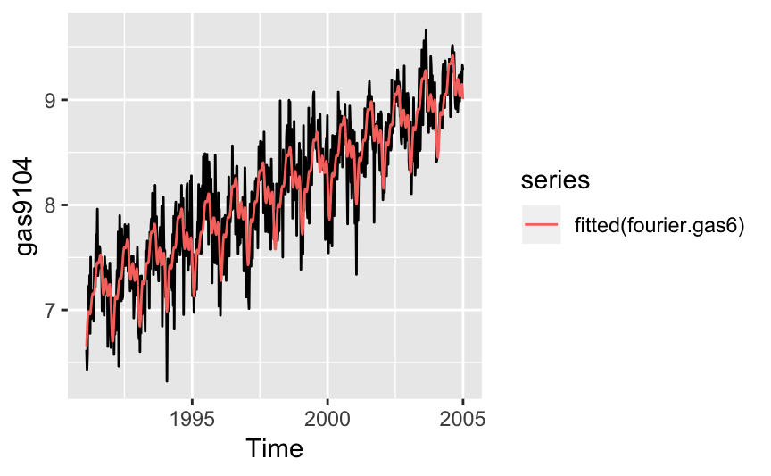

```r
fourier.gas6 <- tslm(gas9104 ~ trend + fourier(gas9104, K=6))
autoplot(gas9104) + autolayer(fitted(fourier.gas6))
```

** m = 4 quarters, so 2 Fourier terms **

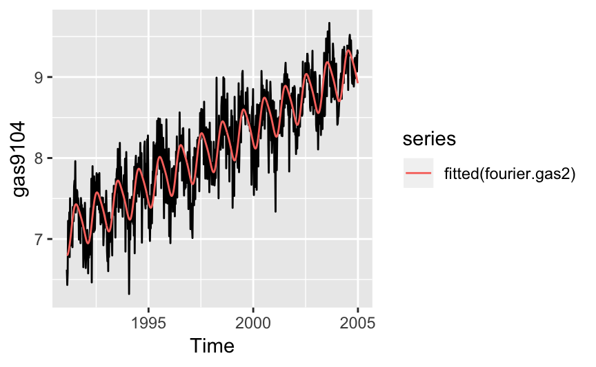

```r
fourier.gas2 <- tslm(gas9104 ~ trend + fourier(gas9104, K=2))
autoplot(gas9104) + autolayer(fitted(fourier.gas2))
```

The model fits the observed data better with more Fourier terms, as with `K = 26`, but this may lead to overfitting.

**6b.** Select the appropriate number of Fourier terms to include by minimising the AICc or CV value.

```r
CV(fourier.gas26)
```

```
           CV           AIC          AICc           BIC
 7.426757e-02 -1.889694e+03 -1.880500e+03 -1.637379e+03
        AdjR2
 8.526098e-01
```

```r
CV(fourier.gas6)
```

```
           CV           AIC          AICc           BIC
    0.0725333 -1902.7534284 -1902.0773721 -1833.9401782
        AdjR2
    0.8474536
```

```r
CV(fourier.gas2)
```

```
           CV           AIC          AICc           BIC
 8.136854e-02 -1.819113e+03 -1.818957e+03 -1.787001e+03
        AdjR2
 8.269569e-01
```

Of the three harmonic regression models, the model with the middle K-value of 6 (or 12 periods) was the best by having the lowest AICc and CV values.

**6c.** Check the residuals of the final model using the `checkresiduals()` function.

Even though the residuals fail the correlation tests, the results are probably not severe enough to make much difference to the forecasts and prediction intervals. (Note that the correlations are relatively small, even though they are significant.)

```
    Breusch-Godfrey test for serial correlation of
    order up to 104

data:  Residuals from Linear regression model
LM test = 147.59, df = 104, p-value = 0.003212
```

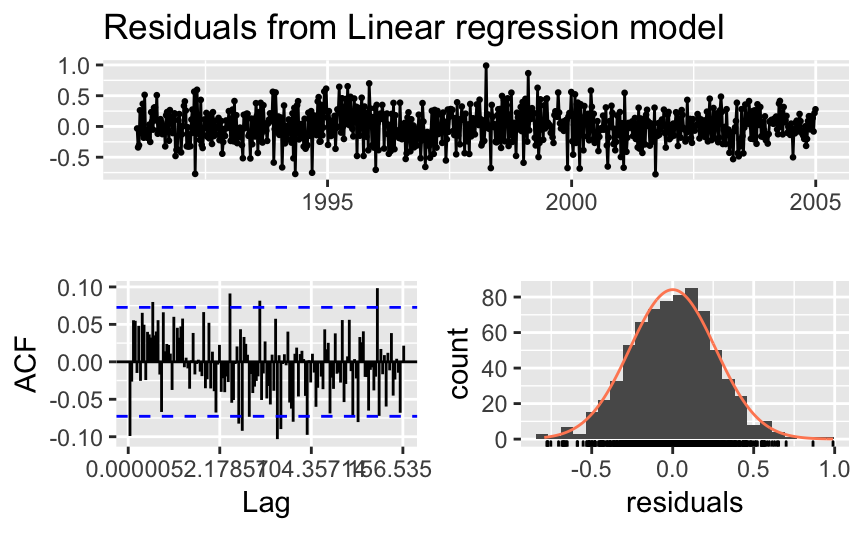

```r
checkresiduals(fourier.gas6)
```

As explained in the textbook, residuals testing indicates that the model exhibits some autocorrelation, as demonstrated by the low p-value in the Breusch-Godfrey test and the ACF plot which has multiple significant lags. However, the residuals distribution plot looks quite normal with only a slight tail to the right.

**6c.** Forecast the next year of data using the following function:

`fc <- forecast(fit, newdata=data.frame(fourier(x,K,h)))`

where `fit` is the fitted model using `tslm()`, `K` is the number of Fourier terms used in creating fit, and `h` is the forecast horizon required.

```r
fc <- forecast(fourier.gas6, newdata=data.frame(fourier(gas9104, 6, 52)))
fc
```

```
         Point Forecast    Lo 80    Hi 80    Lo 95
2005.014       8.862554 8.516528 9.208580 8.332944
2005.033       8.717459 8.371361 9.063556 8.187738
2005.052       8.617995 8.271858 8.964133 8.088215
2005.071       8.594304 8.248168 8.940439 8.064526
2005.090       8.649090 8.302984 8.995196 8.119357
2005.110       8.757619 8.411544 9.103694 8.227934
2005.129       8.879367 8.533309 9.225425 8.349707
2005.148       8.975681 8.629626 9.321737 8.446026
2005.167       9.025281 8.679223 9.371339 8.495622
2005.186       9.030771 8.684714 9.376829 8.501113
2005.205       9.013896 8.667842 9.359949 8.484243
2005.225       9.002604 8.656555 9.348654 8.472958
2005.244       9.016710 8.670663 9.362758 8.487067
2005.263       9.059117 8.713070 9.405165 8.529474
2005.282       9.116435 8.770387 9.462483 8.586791
2005.301       9.167935 8.821886 9.513984 8.638290
2005.320       9.197675 8.851625 9.543724 8.668028
2005.340       9.203318 8.857268 9.549368 8.673671
2005.359       9.197174 8.851124 9.543224 8.667527
2005.378       9.199207 8.853159 9.545256 8.669562
2005.397       9.225985 8.879937 9.572033 8.696341
2005.416       9.281538 8.935491 9.627586 8.751895
2005.435       9.355000 9.008953 9.701048 8.825357
2005.455       9.426204 9.080156 9.772252 8.896560
2005.474       9.476186 9.130137 9.822234 8.946541
2005.493       9.496939 9.150890 9.842988 8.967293
2005.512       9.495159 9.149109 9.841208 8.965513
2005.531       9.487903 9.141854 9.833951 8.958258
2005.550       9.492429 9.146381 9.838477 8.962785
2005.570       9.515645 9.169597 9.861692 8.986001
2005.589       9.548967 9.202919 9.895014 9.019323
2005.608       9.571685 9.225637 9.917732 9.042041
2005.627       9.561482 9.215434 9.907530 9.031837
2005.646       9.506896 9.160847 9.852945 8.977250
2005.665       9.415220 9.069170 9.761269 8.885573
2005.685       9.311393 8.965344 9.657442 8.781747
2005.704       9.227875 8.881827 9.573924 8.698230
2005.723       9.190099 8.844051 9.536147 8.660455
2005.742       9.204548 8.858501 9.550596 8.674905
```

[output cut: 51 more lines]

```
2005.723  9.719743
2005.742  9.734192
2005.761  9.785125
2005.780  9.841832
2005.800  9.873168
2005.819  9.862373
2005.838  9.814900
2005.857  9.755236
2005.876  9.714089
2005.895  9.712090
2005.915  9.748085
2005.934  9.798008
2005.953  9.825308
2005.972  9.798267
2005.991  9.706064
```

**6e.** Plot the forecasts along with the actual data for 2005. What do you find?

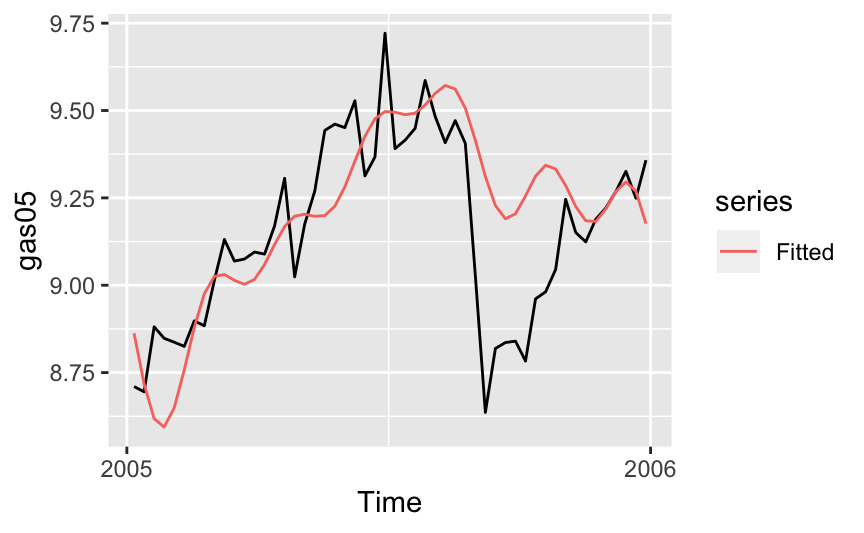

```r
gas05 <- window(gasoline, start=2005, end=2006)
autoplot(gas05) + autolayer(fc$mean, series="Fitted")
```

The fourier forecast roughly matches the general trend of the actual data for 2005, but there seems to be a dramatic drop in the actuals around August that wasn’t expected by the model.

#### 7. Data set `huron` gives the water level of Lake Huron in feet from 1875 to 1972.

**7a.** Plot the data and comment on its features.

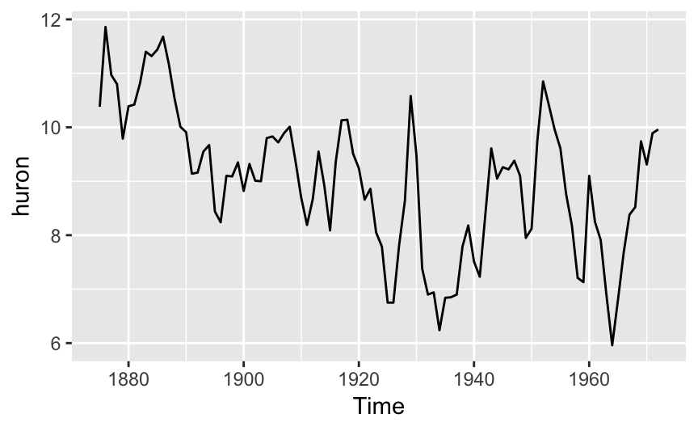

```r
autoplot(huron)
```

The plot shows a general negative trend. There are several shocks in 1925, 1935, 1957, and 1965, which might have been caused by drought.

**7b.** Fit a linear regression and compare this to a [piecewise linear trend model](https://otexts.org/fpp2/nonlinear-regression.html) with a knot at 1915.

```r
huron.fit <- tslm(huron ~ trend)
summary(huron.fit)
```

```
Call:
tslm(formula = huron ~ trend)

Residuals:
     Min       1Q   Median       3Q      Max
-2.50997 -0.72726  0.00083  0.74402  2.53565

Coefficients:
             Estimate Std. Error t value Pr(>|t|)
(Intercept) 10.202037   0.230111  44.335  < 2e-16 ***
trend       -0.024201   0.004036  -5.996 3.55e-08 ***
---
Signif. codes:
0 ‘***’ 0.001 ‘**’ 0.01 ‘*’ 0.05 ‘.’ 0.1 ‘ ’ 1

Residual standard error: 1.13 on 96 degrees of freedom
Multiple R-squared:  0.2725,    Adjusted R-squared:  0.2649
F-statistic: 35.95 on 1 and 96 DF,  p-value: 3.545e-08
```

```r
t <- time(huron)
t.break <- 1915
tb <- ts(pmax(0, t-t.break), start=1875)
huron.pw <- tslm(huron ~ t + tb)
summary(huron.pw)
```

```
Call:
tslm(formula = huron ~ t + tb)

Residuals:
     Min       1Q   Median       3Q      Max
-2.49626 -0.66240 -0.07139  0.85163  2.39222

Coefficients:
             Estimate Std. Error t value Pr(>|t|)
(Intercept) 132.90870   19.97687   6.653 1.82e-09 ***
t            -0.06498    0.01051  -6.181 1.58e-08 ***
tb            0.06486    0.01563   4.150 7.26e-05 ***
---
Signif. codes:
0 ‘***’ 0.001 ‘**’ 0.01 ‘*’ 0.05 ‘.’ 0.1 ‘ ’ 1

Residual standard error: 1.045 on 95 degrees of freedom
Multiple R-squared:  0.3841,    Adjusted R-squared:  0.3711
F-statistic: 29.62 on 2 and 95 DF,  p-value: 1.004e-10
```

The piecewise regression model with a knot at the year 1915 improved upon the straight model (at least for the period up through 1915), with an adjusted R-squared of 0.3711381 vs. 0.2648943 (40.1%) and 1.0454215 vs. 1.1302868 (-7.5%).

**7c.** Generate forecasts from these two models for the period up to 1980 and comment on these.

```r
fcasts.lr <- forecast(huron.fit, h=8)
fcasts.lr
```

```
     Point Forecast    Lo 80    Hi 80    Lo 95     Hi 95
1973       7.806127 6.317648 9.294605 5.516501 10.095752
1974       7.781926 6.292536 9.271315 5.490899 10.072952
1975       7.757724 6.267406 9.248043 5.465269 10.050179
1976       7.733523 6.242259 9.224788 5.439613 10.027434
1977       7.709322 6.217094 9.201550 5.413929 10.004715
1978       7.685121 6.191912 9.178331 5.388219  9.982024
1979       7.660920 6.166712 9.155128 5.362481  9.959359
1980       7.636719 6.141494 9.131943 5.336717  9.936721
```

```r
t.new <- t[length(t)] + seq(8)
tb.new <- tb[length(tb)] + seq(8)
newdata <- cbind(t = t.new, tb=tb.new) %>% as.data.frame()
fcasts.pw <- forecast(huron.pw , newdata=newdata)
fcasts.pw
```

```
     Point Forecast    Lo 80    Hi 80    Lo 95    Hi 95
1973       8.455119 7.063583 9.846655 6.314483 10.59575
1974       8.454992 7.061518 9.848467 6.311374 10.59861
1975       8.454866 7.059398 9.850333 6.308182 10.60155
1976       8.454739 7.057225 9.852253 6.304906 10.60457
1977       8.454612 7.054998 9.854227 6.301549 10.60768
1978       8.454486 7.052717 9.856254 6.298109 10.61086
1979       8.454359 7.050384 9.858334 6.294587 10.61413
1980       8.454232 7.047997 9.860467 6.290984 10.61748
```

Although the piecewise model has higher point forecasts than the linear model, the prediction interval is tighter.

```r
lr80 <- mean(fcasts.lr$upper[,1]-fcasts.lr$lower[,1])
pw80 <- mean(fcasts.pw$upper[,1]-fcasts.pw$lower[,1])
lr95 <- mean(fcasts.lr$upper[,2]-fcasts.lr$lower[,2])
pw95 <- mean(fcasts.pw$upper[,2]-fcasts.pw$lower[,2])
```

The average size of the 80% confidence interval for the linear model was 2.9835803 while that for the piecewise model was 2.7973958, which was -6.24% lower.

The average size of the 95% confidence interval for the linear model was 4.5894384 while that for the piecewise model was 4.3033077, which was -6.23% lower.

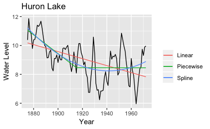

```r
huron.spline <- tslm(huron ~ t + I(t^2) + I(t^3))
fcasts.spl <- forecast(huron.spline, newdata=newdata)
autoplot(huron) + autolayer(fitted(huron.fit), series="Linear") + autolayer(fitted(huron.pw), series="Piecewise") + autolayer(fitted(huron.spline), series="Spline") + xlab("Year") + ylab("Water Level") + ggtitle("Huron Lake") + guides(color=guide_legend(title=" "))
```